# Analyse descriptive des variables

## Description des variables

### Diagnostic

C’est une variable catégorielle binaire qui renseigne sur le diagnostic associé à l’échantillon. Elle prend soit la valeur “B” pour désigner une tumeur bénine, soit la valeur “M” pour une tumeur maligne.

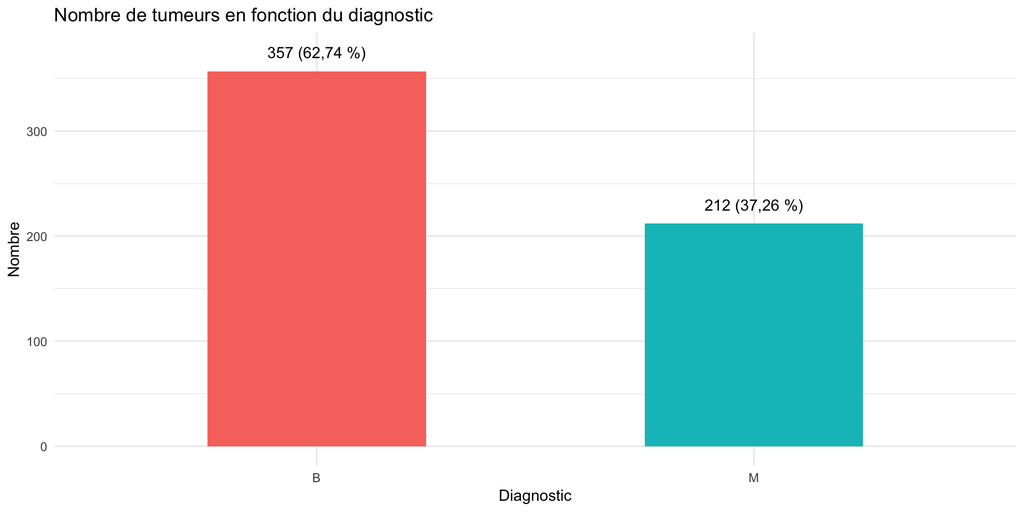

Ainsi, on voit que deux tiers des tumeurs sont bénignes.

### Taille du noyau

Trois variables numériques continues renseignent sur la **taille** du noyau des cellules : le rayon (radius), le périmètre (perimeter) et l’aire (area). Elles sont corrélées entre elles et liées par des relations mathématiques.

#### Rayon

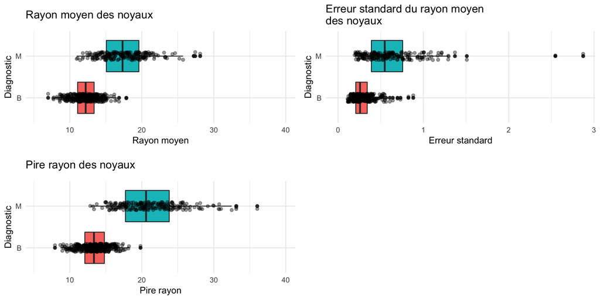

#### Périmètre

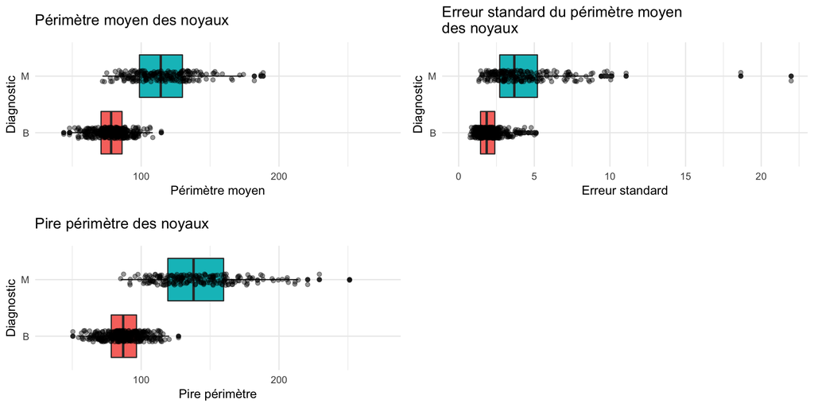

#### Aire

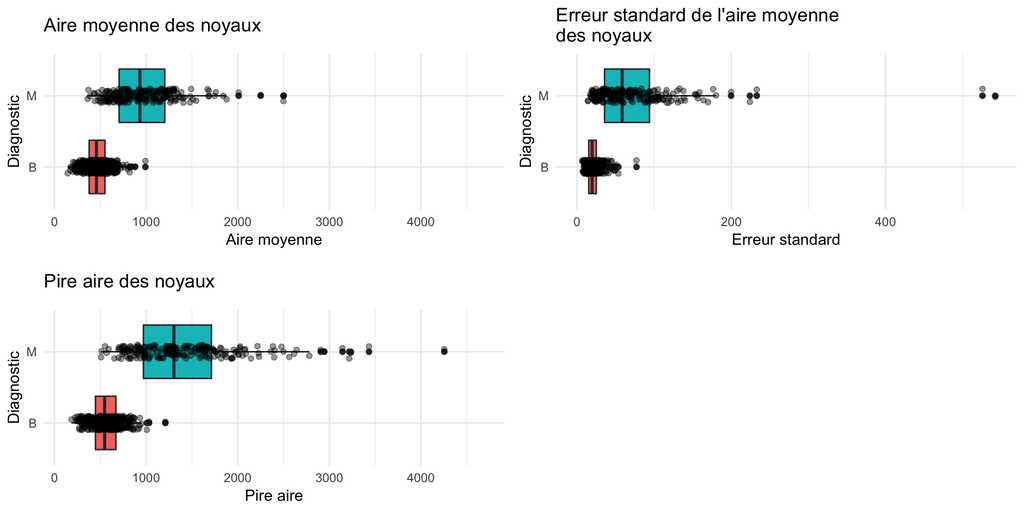

### Aspect

L’aspect du noyau est raporté par deux variables numériques continues : la compacité et la texture. Comme pour la taille du noyau, les valeurs pour les tumeurs malignes sont plus élevées que pour les bénignes.

#### Compactness

La compacité est calculée par la formule suivante : $\frac{perimeter^2}{area} - 1$

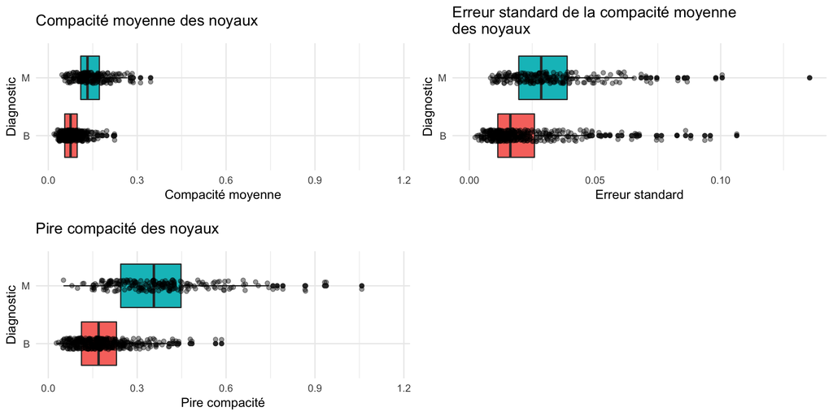

#### Texture

La texture du noyau est calculée à partie de l’ecart-type des valeurs des échelles de gris.

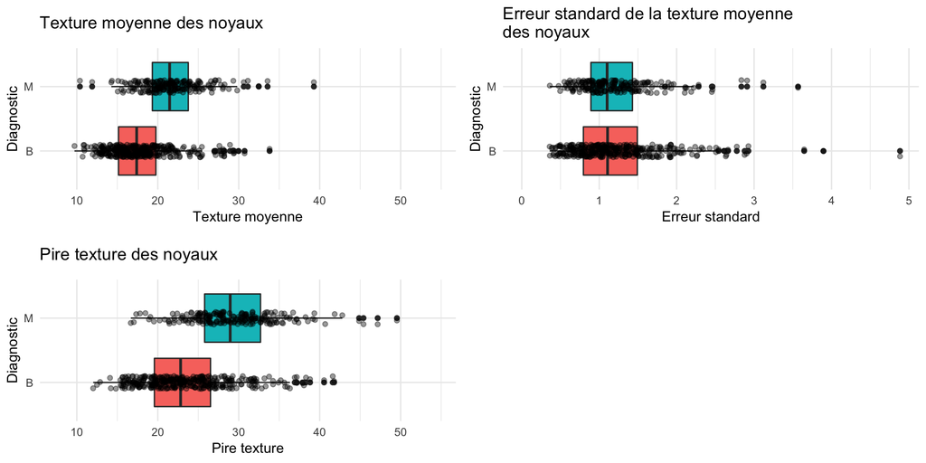

### Forme du noyau

Cinq variables numériques continues ont été mesurées pour rendre compte de la forme du noyau. On voit que la différence entre les cellules malignes et bénignes est la plus marquée pour les variables `concavity` et `concave points`. Les cellules tumorales malignes ont donc un noyau avec des contours plus concaves par rapport aux cellules bénines. La dimension fractale par contre n’est pas différente entre les deux types de cellules.

#### Smoothness

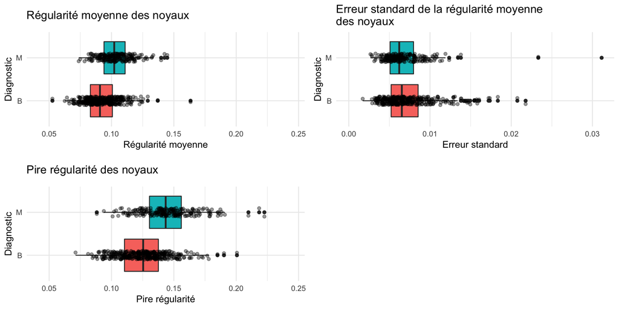

#### Concavity

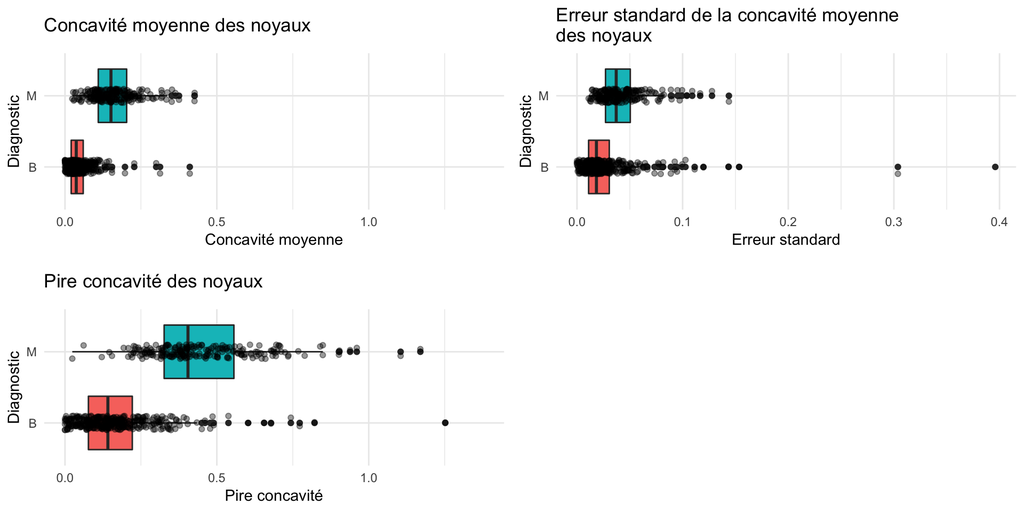

#### Concave points

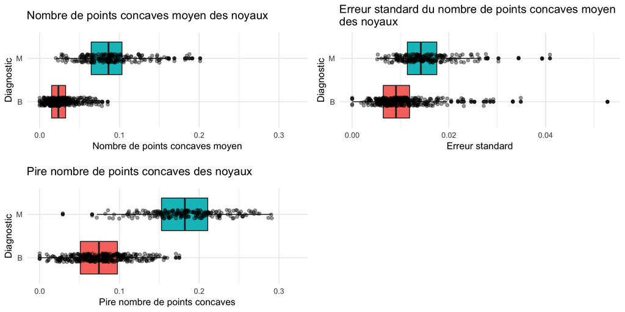

#### Symmetry

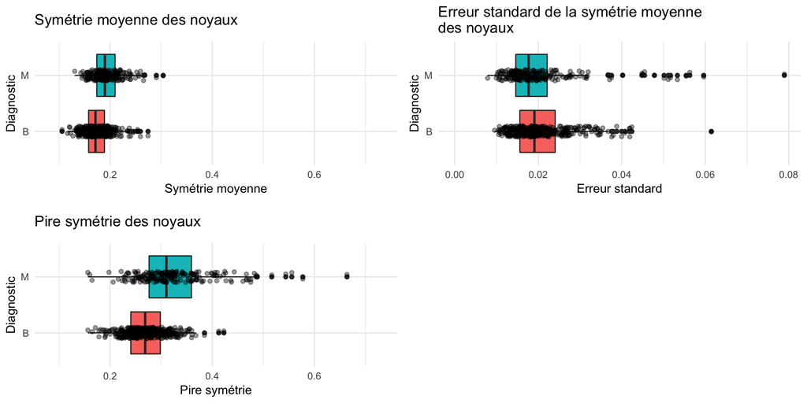

#### Fractal dimension

La dimension fractale est une variable numérique continue. Elle renseigne sur l’irrégularité des contours du noyau des cellules.

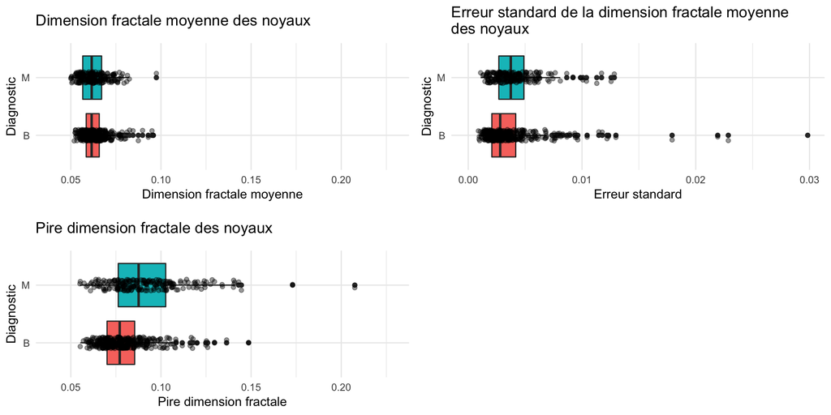

## Variables pertimentes

La figure ci dessous montre les coefficients de corrélation enntre le diagnostic et les autres variables.

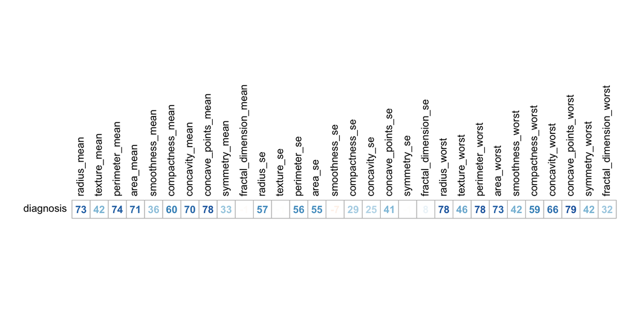

Le graphique ci dessous montre le nuage de point obtenu quand on croise les deux variables les plus corrélées :

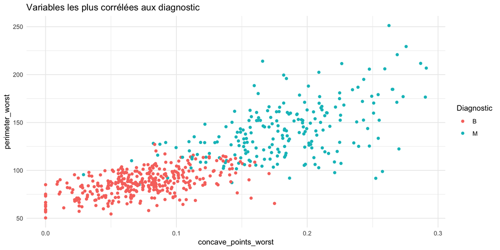